# act_report

## Analyzation of #WeRateDogs twitter data

```python
import pandas as pd
import matplotlib
import matplotlib.pyplot as plt
%matplotlib inline
from pandas.plotting import scatter_matrix
```

### Lets take a look at our cleaned #WeRateDogs twitter data

```python
df = pd.read_csv("twitter_archive_master.csv", index_col=0)
df.info()
```

```
<class 'pandas.core.frame.DataFrame'>
Int64Index: 1994 entries, 0 to 1993
Data columns (total 12 columns):
tweet_id            1994 non-null int64
timestamp           1994 non-null object
source              1994 non-null object
text                1994 non-null object
name                1994 non-null object
gender              1994 non-null object
dog_stage           1994 non-null object
rating              1994 non-null float64
breed               1994 non-null object
breed_confidence    1994 non-null float64
retweet_count       1994 non-null int64
favorite_count      1994 non-null int64
dtypes: float64(2), int64(3), object(7)
memory usage: 202.5+ KB
```

```python
### Lets see the Stats about the numerical variables in the dataset.
df.describe()
```

|  | tweet_id | rating | breed_confidence | retweet_count | favorite_count |
| --- | --- | --- | --- | --- | --- |
| count | 1.994000e+03 | 1994.000000 | 1994.000000 | 1994.000000 | 1994.000000 |
| mean | 7.358508e+17 | 11.577623 | 0.464991 | 2766.753260 | 8895.725677 |
| std | 6.747816e+16 | 40.649596 | 0.339470 | 4674.698447 | 12213.193181 |
| min | 6.660209e+17 | 0.000000 | 0.000000 | 16.000000 | 81.000000 |
| 25% | 6.758475e+17 | 10.000000 | 0.140466 | 624.750000 | 1982.000000 |
| 50% | 7.084748e+17 | 11.000000 | 0.459130 | 1359.500000 | 4136.000000 |
| 75% | 7.877873e+17 | 12.000000 | 0.776387 | 3220.000000 | 11308.000000 |
| max | 8.924206e+17 | 1776.000000 | 0.999956 | 79515.000000 | 132810.000000 |

### Lets see the retweet_count and favorite_count over time

```python
# It seems that when we store the dataframe to csv the datetime object is not saved at it is.
#Instead it is saved as an object from this url
# https://stackoverflow.com/questions/30298144/datetime-format-change-when-save-to-csv-file-python.
# So the cleaning step of converting timestamp to datetime is useless, still I am going to keep it.
# Convert timestamp column from object to datetime
df['timestamp'] = pd.to_datetime(df['timestamp'])

df.set_index('timestamp', inplace=True)
```

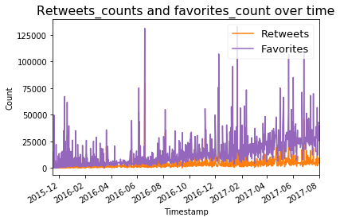

```python
df['retweet_count'].plot(color = 'tab:orange', label='Retweets')
df['favorite_count'].plot(color = 'tab:purple', label='Favorites')
plt.style.use('seaborn-talk')
plt.legend(loc='upper right')
plt.xlabel('Timestamp')
plt.ylabel('Count')
plt.title('Retweets_counts and favorites_count over time')
# plt.savefig('retweets_favorites.png')
plt.show()
```

Here, we can see that retweets and favorites counts are increasing over time. There are some tweets which has very high favorites counts above than 5000 .

### Lets see the corelation between different variables in the data

#### Lets use pandas corr() function and use scatter_matrix which is similar to ggpairs in R which we have learned in EDA lesson.

```python
df.corr(method='pearson')
```

|  | tweet_id | rating | breed_confidence | retweet_count | favorite_count |
| --- | --- | --- | --- | --- | --- |
| tweet_id | 1.000000 | 0.028257 | 0.147109 | 0.405404 | 0.655276 |
| rating | 0.028257 | 1.000000 | -0.022961 | 0.018652 | 0.016362 |
| breed_confidence | 0.147109 | -0.022961 | 1.000000 | 0.036822 | 0.086394 |
| retweet_count | 0.405404 | 0.018652 | 0.036822 | 1.000000 | 0.912947 |
| favorite_count | 0.655276 | 0.016362 | 0.086394 | 0.912947 | 1.000000 |

```python
df[['rating','breed_confidence','retweet_count','favorite_count']].corr(method='pearson')
```

|  | rating | breed_confidence | retweet_count | favorite_count |
| --- | --- | --- | --- | --- |
| rating | 1.000000 | -0.022961 | 0.018652 | 0.016362 |
| breed_confidence | -0.022961 | 1.000000 | 0.036822 | 0.086394 |
| retweet_count | 0.018652 | 0.036822 | 1.000000 | 0.912947 |
| favorite_count | 0.016362 | 0.086394 | 0.912947 | 1.000000 |

[output not shown]

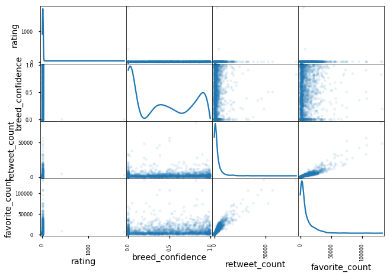

```python
scatter_matrix(df[['rating','breed_confidence','retweet_count','favorite_count']], alpha=0.1, diagonal='kde')
```

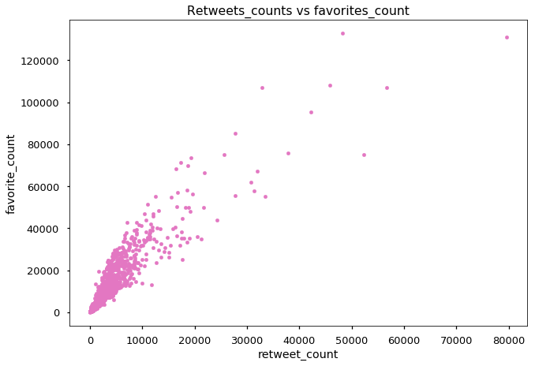

```python
df.plot(kind='scatter', x='retweet_count', y='favorite_count',color = 'tab:pink')
plt.xlabel('retweet_count')
plt.ylabel('favorite_count')
plt.title('Retweets_counts vs favorites_count')
plt.show()
```

From the above statistics and plot we can see that there is a strong positive corelation between retweet counts and favorite counts. It means that people make such tweets favorite which gets retweeted more. It makes sense because people make retweets which they find interesting and the tweet gets circulated more resulting such tweets get more favorite count.

### Now lets see which breed of dog's photo #WeRateDogs gets more often for rating.

```python
df['breed'].value_counts()
```

```
unknown                        308
golden_retriever               158
Labrador_retriever             108
Pembroke                        95
Chihuahua                       91
pug                             62
toy_poodle                      51
chow                            48
Samoyed                         42
Pomeranian                      42
malamute                        33
French_bulldog                  31
Chesapeake_Bay_retriever        31
cocker_spaniel                  30
miniature_pinscher              25
Eskimo_dog                      22
Staffordshire_bullterrier       21
German_shepherd                 21
Cardigan                        21
Shih-Tzu                        20
Siberian_husky                  20
beagle                          20
Rottweiler                      19
Shetland_sheepdog               19
Maltese_dog                     19
kuvasz                          18
Lakeland_terrier                18
basset                          17
Italian_greyhound               17
West_Highland_white_terrier     16
                              ...
Welsh_springer_spaniel           4
Gordon_setter                    4
giant_schnauzer                  4
Rhodesian_ridgeback              4
Tibetan_terrier                  4
bluetick                         4
Leonberg                         3
curly-coated_retriever           3
toy_terrier                      3
komondor                         3
Afghan_hound                     3
Irish_water_spaniel              3
briard                           3
Greater_Swiss_Mountain_dog       3
Brabancon_griffon                3
cairn                            3
wire-haired_fox_terrier          2
Australian_terrier               2
Appenzeller                      2
groenendael                      2
Sussex_spaniel                   2
black-and-tan_coonhound          2
clumber                          1
silky_terrier                    1
standard_schnauzer               1
EntleBucher                      1
Scotch_terrier                   1
Bouvier_des_Flandres             1
Japanese_spaniel                 1
Irish_wolfhound                  1
Name: breed, Length: 114, dtype: int64
```

From the above stats, golden retriever's photo gets #WeRateDogs more often for rating and Labrador_retriever after that.

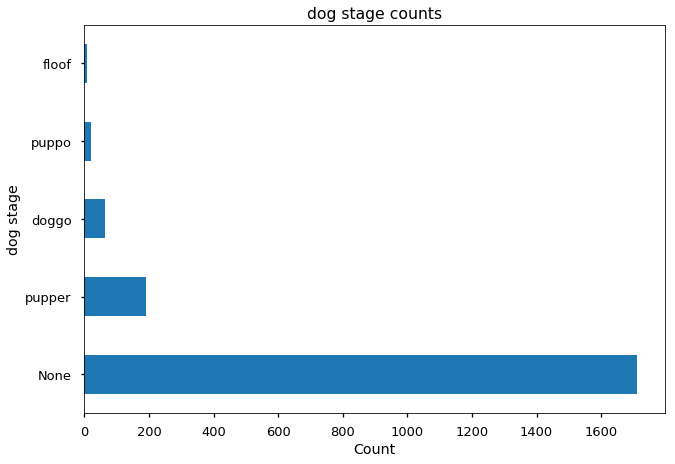

```python
df['dog_stage'].value_counts().plot(kind = 'barh')
plt.xlabel('Count')
plt.ylabel('dog stage')
plt.title('dog stage counts')
plt.show()
```

From the above plot, it is clear that #WeRateDogs give pupper stage more often while floof is very rarely given.

### male vs female dog

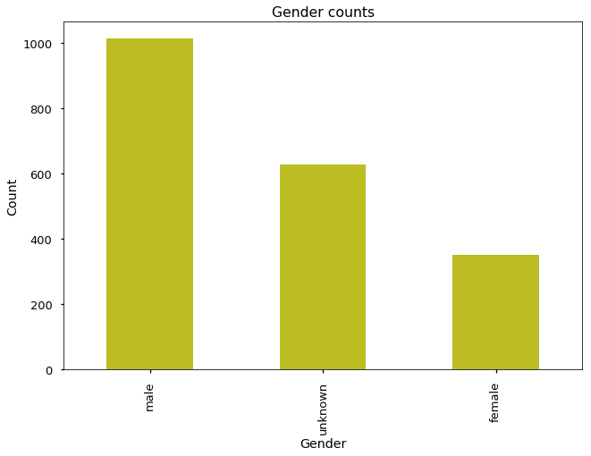

```python
df['gender'].value_counts().plot(kind = 'bar', color = 'tab:olive')
plt.xlabel('Gender')
plt.ylabel('Count')
plt.title('Gender counts')
plt.show()
```

From above plot, we see there are more male dogs than female dogs but I am not sure about this inference because the gender data extraction from text was not efficiently done as well as we can see there are lots of dogs whos gender is unknown.

### Which breed of dog gets higher ratings.

```python
breed_df = df.copy()
# Lets remove outliers i.e make the criteria for higher ratings between 11 to 17
breed_df[(breed_df.rating > 11.0) & (breed_df.rating < 17.0) & (breed_df.breed != 'unknown')].breed.value_counts()
```

```
golden_retriever                  96
Pembroke                          52
Labrador_retriever                48
Chihuahua                         36
chow                              26
Samoyed                           23
toy_poodle                        21
French_bulldog                    16
Pomeranian                        15
cocker_spaniel                    15
pug                               13
Eskimo_dog                        12
Chesapeake_Bay_retriever          12
malamute                          11
kuvasz                            10
German_shepherd                   10
Rottweiler                        10
Siberian_husky                     9
Cardigan                           9
miniature_pinscher                 9
Pekinese                           8
Great_Pyrenees                     7
Border_terrier                     6
Old_English_sheepdog               6
Shetland_sheepdog                  6
basset                             6
Bernese_mountain_dog               6
Border_collie                      6
Staffordshire_bullterrier          6
American_Staffordshire_terrier     5
                                  ..
papillon                           1
basenji                            1
silky_terrier                      1
Dandie_Dinmont                     1
toy_terrier                        1
komondor                           1
Newfoundland                       1
Irish_terrier                      1
Rhodesian_ridgeback                1
Ibizan_hound                       1
keeshond                           1
Norwich_terrier                    1
standard_schnauzer                 1
curly-coated_retriever             1
Appenzeller                        1
cairn                              1
English_setter                     1
miniature_schnauzer                1
Australian_terrier                 1
wire-haired_fox_terrier            1
black-and-tan_coonhound            1
Mexican_hairless                   1
Tibetan_terrier                    1
Bouvier_des_Flandres               1
German_short-haired_pointer        1
Boston_bull                        1
clumber                            1
bull_mastiff                       1
Lhasa                              1
Saint_Bernard                      1
Name: breed, Length: 104, dtype: int64
```

### Final thoughts

The data contains verious breeds of Dogs. But there some variables which I have not extracted properly from the text part of the tweet like gender so for gender of dogs we need some extra data or another method of gender extraction. The data generated by Neural network played an important role as it gives us the dogs breed which is very helpful for insights. The #WeRateDogs twitter data is very interesting and surprising.